# Activity 03: Summary statistics, frequency distribution, and basic graphical representation

Javi Pascual

2026-06-01

## Summary of Answers

### Most and least observed species

- **Most Observed Species:** Phlo (377 observations)
- **Least Observed Species:** Babu, Geat, Hety, Bosc, Drru,Apbo (1 observation each)

### Mean observations

[output not shown]

INTERPRETATION

In the data from the article of Supsup et al. (2020) entitled “Variation in species richness, composition and herpetological community structure across a tropical habitat gradient of Palawan Island, Philippines”, it can be seen that in terms of the total community observations across the dataset, Advanced Secondary Growth (ASG) had the highest amount with 58, which is then followed by Old Growth Forest (OGF, 48), Early Secondary Growth (ESG, 28), and Cultivation (CVT, 1), which aligns with the aforementioned paper. However, the area with the most species counts is the OGF with a significant different in amount of 350, followed by ASG (25), CVT (8), and ESG (0). It can then be inferred that despite the amount of observations in ASG, it does not necessarily mean that it also hosts the most species-rich area.

The mean distribution provides insight into the dominant and specialized species in the different study sites. The most observed species known aiss “Phlo” and the least observed species are Babu, Geat, Hety, Bosc, Drru, and Apbo. As for the Species Total Abundance (SPPTotal), it is seen in the scatterplot that it `most apparent at lower elevations and would greatly decrease between 200 and 400 meters. In the histogram, it is heavily skewed with most of the obsercations found in the left part of the histogram. This can be inferred to as the observed species to prefer the temperature or environment of that specific area as opposed to the other areas.

END

```r
## Set working directory ##
setwd("C:/Users/Blight/Desktop/S.Y 25-26 Term 3/LBBBI27")
getwd()
```

```
## [1] "C:/Users/Blight/Desktop/S.Y 25-26 Term 3/LBBBI27"
```

```r
## Data cleaning ##
my_data <- read.csv("Data.csv")
remove_NA <- complete.cases(my_data)
head(my_data[remove_NA, ])
```

```
##      Sites     Long     Lat Htypes Elev SPPTotal Babu Inph Liac Lipa Ocla Leta
## 1 ASG_ET1# 118.3962 9.37437    ASG  257        0    0    0    0    0    0    0
## 2 ASG_ET4# 118.3990 9.37250    ASG  215        0    0    0    0    0    0    0
## 3 ESG_ET5# 118.4008 9.37183    ESG  188        0    0    0    0    0    0    0
## 4  CVT_ET6 118.4056 9.36728    CVT  105        0    0    0    0    0    0    0
## 5  OGF_ET8 118.3861 9.37160    OGF  662        1    0    0    0    0    0    0
## 6 OGF_ET10 118.3840 9.37247    OGF  754        1    0    0    0    0    0    0
##   Meli Chfu Pumo Sasa Stnu Phev Phlo Pole Poma Brsp Cyre Geat Gege Gemo Hety
## 1    0    0    0    0    0    0    0    0    0    0    0    0    0    0    0
## 2    0    0    0    0    0    0    0    0    0    0    0    0    0    0    0
## 3    0    0    0    0    0    0    0    0    0    0    0    0    0    0    0
## 4    0    0    0    0    0    0    0    0    0    0    0    0    0    0    0
## 5    0    0    0    0    0    0    3    0    0    0    0    0    0    0    0
## 6    0    0    0    0    0    0    7    0    0    0    0    0    0    0    0
##   Eumu Bosc Dema Drru Apbo Trsu
## 1    0    0    0    0    0    0
## 2    0    0    0    0    0    0
## 3    0    0    0    0    0    0
## 4    0    0    0    0    0    0
## 5    0    0    0    0    0    0
## 6    0    0    0    0    0    0
```

```r
clean_data <- my_data[remove_NA, ]
```

```r
## Elevation ##
my_elevation <- clean_data$Elev

mean(my_elevation)
```

```
## [1] 379.3878
```

```r
sd(my_elevation)
```

```
## [1] 240.5951
```

```r
range(my_elevation)
```

```
## [1]   60 1020
```

```r
## Species data (G-AG) ##
my_speciesdata <- clean_data [ , 7:33]
print(my_speciesdata)
```

```
##    Babu Inph Liac Lipa Ocla Leta Meli Chfu Pumo Sasa Stnu Phev Phlo Pole Poma
## 1     0    0    0    0    0    0    0    0    0    0    0    0    0    0    0
## 2     0    0    0    0    0    0    0    0    0    0    0    0    0    0    0
## 3     0    0    0    0    0    0    0    0    0    0    0    0    0    0    0
## 4     0    0    0    0    0    0    0    0    0    0    0    0    0    0    0
## 5     0    0    0    0    0    0    0    0    0    0    0    0    3    0    0
## 6     0    0    0    0    0    0    0    0    0    0    0    0    7    0    0
## 7     0    0    0    0    0    0    0    0    0    0    0    0   22    0    0
## 8     0    0    0    0    0    0    0    0    0    0    0    0   30    0    0
## 9     0    0    0    0    0    0    0    0    0    0    0    0    1    0    0
## 10    0    0    0    0    0    0    0    0    0    0    0    0    5    0    0
## 11    0    0    0    0    0    0    0    0    0    0    0    0   30    0    0
## 12    0    0    0    0    0    0    0    0    0    0    0    0   22    0    0
## 13    0    0    0    0    0    0    0    0    0    0    0    0   19    0    0
## 14    0    0    0    0    0    0    0    0    0    0    0    0    8    0    0
```

[output cut: 85 more lines]

```r
## Typical loop ##
list_species <- list()

min_count <- Inf
max_count <- -1
min_species <- NULL
max_species <- NULL
current_name <- NULL
current_count <- -1
i <- 0

for (i in 1:27) {
  current_count <- sum(my_speciesdata[ , i])
  current_name <- names(my_speciesdata) [i]

  if (current_count < min_count) {
    min_count <- current_count
    min_species <- current_name
  } else if (current_count == min_count) {
    min_species <- c(min_species, current_name)
  }

  if (current_count > max_count) {
    max_count <- current_count
    max_species <- current_name
  } else if(current_count == max_count) {
    max_species <- c(max_species, current_name)
  }

  i <- i + 1
}

print("Least observations:")
```

```
## [1] "Least observations:"
```

```r
print(min_species)
```

```
## [1] "Babu" "Geat" "Hety" "Bosc" "Drru" "Apbo"
```

```r
print(min_count)
```

```
## [1] 1
```

```r
# WILL PRINT
# [1] "Least observations:"
# [1] "Babu" "Geat" "Hety" "Bosc" "Drru" "Apbo"
# [1] 1
#

print("Most observations:")
```

```
## [1] "Most observations:"
```

```r
print(max_species)
```

```
## [1] "Phlo"
```

```r
print(max_count)
```

```
## [1] 377
```

```r
# WILL PRINT
# [1] "Most observations:"
# [1] "Phlo"
# [1] 377



## Compact loop ##
species_counts <- sapply(my_speciesdata, sum)

min_spcounts <- min(species_counts)
max_spcounts <- max(species_counts)

min_spname <- names(species_counts[species_counts == min_spcounts])
max_spname <- names(species_counts[species_counts == max_spcounts])

print("Least observations:")
```

```
## [1] "Least observations:"
```

```r
print(min_spname)
```

```
## [1] "Babu" "Geat" "Hety" "Bosc" "Drru" "Apbo"
```

```r
print(min_spcounts)
```

```
## [1] 1
```

```r
# WILL PRINT
# [1] "Least observations:"
# [1] "Babu" "Geat" "Hety" "Bosc" "Drru" "Apbo"
# [1] 1


print("Most observations:")
```

```
## [1] "Most observations:"
```

```r
print(max_spname)
```

```
## [1] "Phlo"
```

```r
print(max_spcounts)
```

```
## [1] 377
```

```r
# WILL PRINT
# [1] "Most observations:"
# [1] "Phlo"
# [1] 377
```

```r
## Htypes ##
ASG_count <- 0
CVT_count <- 0
ESG_count <- 0
OGF_count <- 0
combine_htypes <- cbind(clean_data["Htypes"], clean_data["Babu"], clean_data["Geat"], clean_data["Hety"], clean_data["Bosc"], clean_data["Drru"], clean_data["Apbo"], clean_data["Phlo"])

mostsp_htmean <- tapply(combine_htypes$Phlo, combine_htypes$Htypes, mean)

split_ht <- split (combine_htypes, combine_htypes$Htypes)

ht_mean <- sapply(split_ht, function(x) {
    colMeans(x[ ,2:8])
})

ht_sum <- sapply(split_ht, function(x) {
    sum(x[,2:8])
})

print(ht_sum)
```

```
## ASG CVT ESG OGF
##  25   8   0 350
```

```r
# WILL PRINT
# ASG CVT ESG OGF
# 25   8   0 350
```

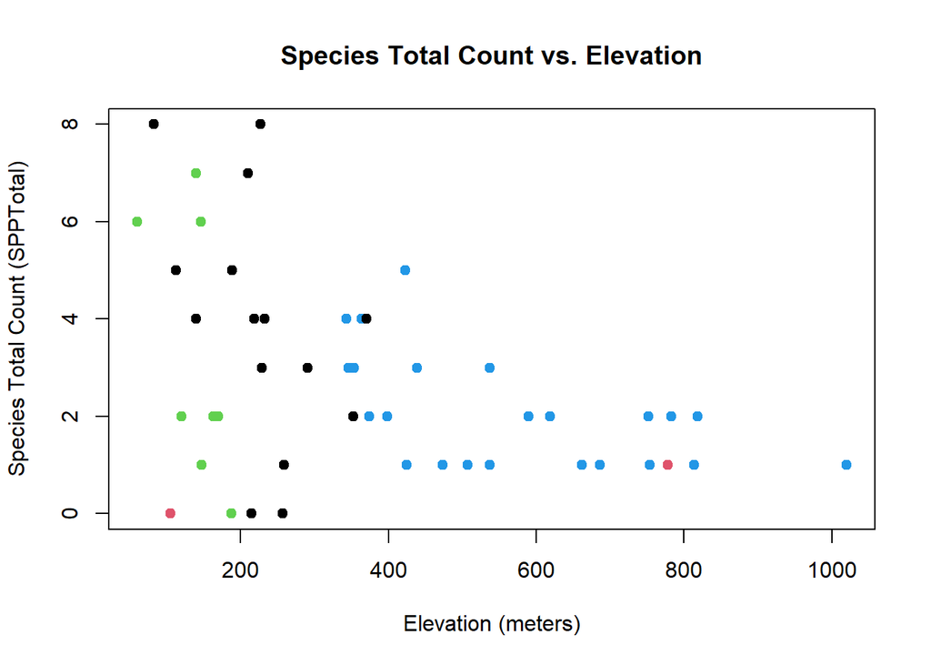

```r
## Plots ##
plot_all <- clean_data[ , c("Htypes", "Elev", "SPPTotal")]

# Scatter plot #
plot(x = plot_all$Elev, y = plot_all$SPPTotal, xlab = "Elevation (meters)", ylab = "Species Total Count (SPPTotal)", main = "Species Total Count vs. Elevation", col = as.factor(plot_all$Htypes), pch = 19)
```

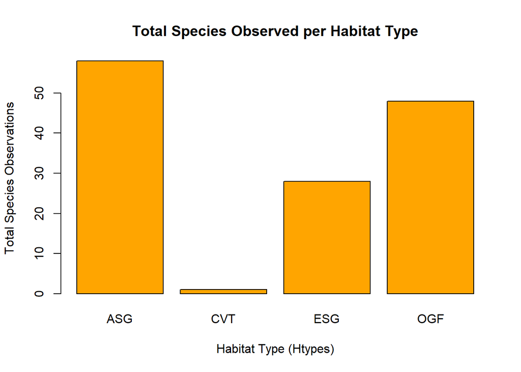

```r
total_habitat <- tapply(plot_all$SPPTotal, plot_all$Htypes, sum)

# Bar plot #
barplot(total_habitat, xlab = "Habitat Type (Htypes)", ylab = "Total Species Observations", main = "Total Species Observed per Habitat Type", col = "orange")
```

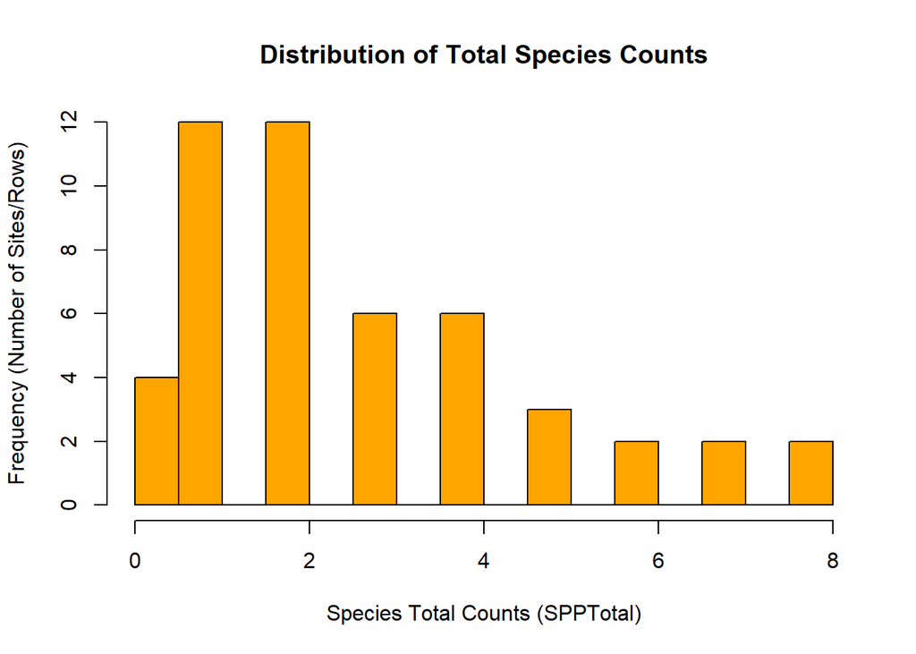

```r
# Histogram #
hist(plot_all$SPPTotal, xlab = "Species Total Counts (SPPTotal)", ylab = "Frequency (Number of Sites/Rows)", main = "Distribution of Total Species Counts", col = "orange", breaks = 12)
```